# k Nearest Neighbor

Question 0

1. What is the difference between regression and classification?

Regression uses covariates to predict variable outome whereas classification uses features or covariates to predict categorical variables.

2. What is a confusion table? What does it help us understand about a model's performance?

Confustion table shows the relationship between actual and predicted values, also showing the correct predictions made by the model and errors when miscalssifying labels

3. Define accuracy. Can an accurate model be flawed for practical use? Explain.

accuracy is the percentage/proportion of correctly predicted labels. For a models performance, while it can be accurate, it can still have errors that make it impractical

4. What does the SSE quantify about a particular model?

It's a sum of squares that measures variability. It measures the sqaured errors produced by a model and involves finding the difference between actual and predicted values, squaring to sum across all the predictions. Outcome is a metric that shows how far the model deviates from actual values.

5. What are overfitting and underfitting?

Overfitting is when a model does well on training data but not on test data. This happens when the model can't generalzie to new data. Underfitting is when the model does poorly on training data and can't generalize to new data. It could be because the model is too simple for the data or doesn't know enough about the data points.

6. Why does splitting the data into training and testing sets, and choosing k by evaluating accuracy or SSE on the test set, improve model performance?

Because the training set can be used to teach the model to recognize patterns while testing set is used to validate the model's predictions. So as its on new data, putting the model in practice on new data not introduced gives a better measure of how it will perform.

7. With classification, we can report a class label as a prediction or a probability distribution over class labels. Please explain the strengths and weaknesses of each approach.

On one hand, it can provide a result that is more simple and easy to interpret. However, it can also have less information such as about probability, so the model's confidence in that prediction is unclear.

Question 1

```python
import numpy as np
import pandas as pd
```

```python
df = pd.read_csv('/Users/angievasquez/Downloads/USA_cars_datasets.csv')
```

```python
df = df.loc[:,['price','year','mileage'] ]
print(df.shape)
print(df.describe())
df.head()
```

```
(2499, 3)
              price         year       mileage
count   2499.000000  2499.000000  2.499000e+03
mean   18767.671469  2016.714286  5.229869e+04
std    12116.094936     3.442656  5.970552e+04
min        0.000000  1973.000000  0.000000e+00
25%    10200.000000  2016.000000  2.146650e+04
50%    16900.000000  2018.000000  3.536500e+04
75%    25555.500000  2019.000000  6.347250e+04
max    84900.000000  2020.000000  1.017936e+06
```

|  | price | year | mileage |
| --- | --- | --- | --- |
| 0 | 6300 | 2008 | 274117 |
| 1 | 2899 | 2011 | 190552 |
| 2 | 5350 | 2018 | 39590 |
| 3 | 25000 | 2014 | 64146 |
| 4 | 27700 | 2018 | 6654 |

No Na's to handle

```python
def maxmin(x):
    u = (x-min(x))/(max(x)-min(x))
    return u

df['year'] = maxmin(df['year'])
df['mileage'] = maxmin(df['mileage'])
```

```python
from sklearn.model_selection import train_test_split
y = df['price']
X = df.drop('price',axis=1)
X_train, X_test, y_train, y_test = train_test_split(X,y,test_size=.2,random_state=100)
```

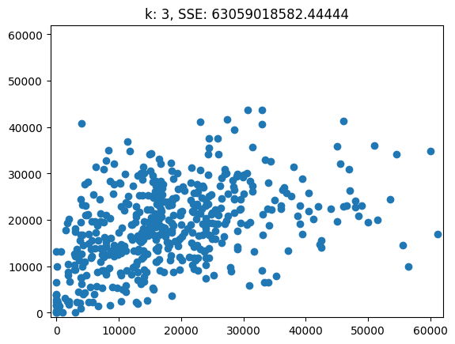

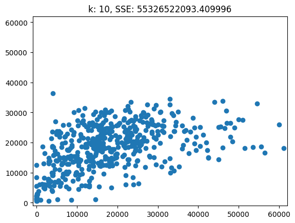

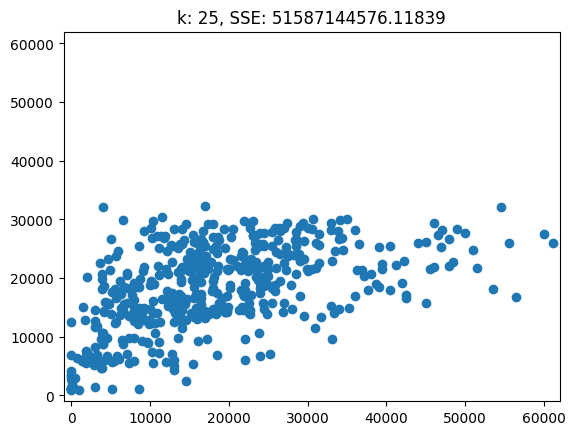

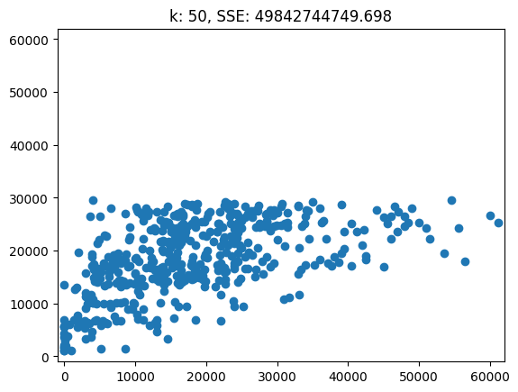

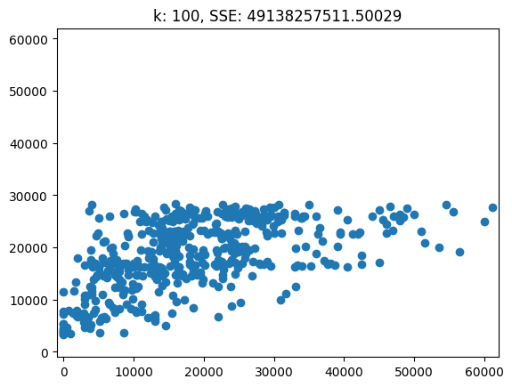

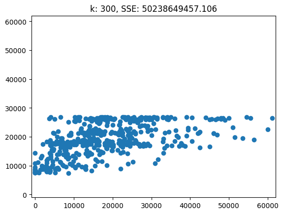

```python
from sklearn.neighbors import KNeighborsRegressor
import matplotlib.pyplot as plt

for k in [3,10,25,50,100,300]:
    model = KNeighborsRegressor(n_neighbors=k).fit(X_train,y_train)
    y_hat = model.predict(X_test)
    SSE = np.sum( (y_test-y_hat)**2 )
    #
    plot, axes = plt.subplots()
    plt.scatter(y_test,y_hat)
    plt.title('k: '+str(k)+', SSE: '+str(SSE))
    axes.set_ylim(-1000, 62000)
    axes.set_xlim(-1000, 62000)
    plt.show()
```

Clustered towards teh right and predicted values flatten and variability for price gets smaller

```python
k_bar = 200
k_grid = np.arange(1,k_bar) # The range of k's to consider
SSE = np.zeros(k_bar)

for k in range(k_bar):
    fitted_model = KNeighborsRegressor(n_neighbors=k+1).fit(X_train,y_train)
    y_hat = fitted_model.predict(X_test) # Predict values for test set
    SSE[k] = np.sum( (y_test-y_hat)**2 ) # Save the computed SSE

SSE_min = np.min(SSE) # Lowest recorded SSE
min_index = np.where(SSE==SSE_min) # Find the indices of y that equal the minimum
k_star = k_grid[min_index] # Find the optimal value of k
print(k_star)
```

```
[77]
```

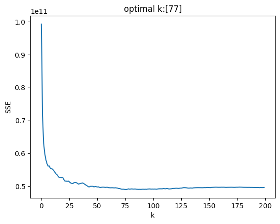

```python
plt.plot(np.arange(0,k_bar),SSE) # Plot SSE by k
plt.xlabel("k")
plt.title("optimal k:"+str(k_star))
plt.ylabel('SSE')
plt.show()
```